# Bioinformatics with R

2023-01-13

## What is R?

The R environment combines: * effective handling of big data * collection of integrated tools * graphical facilities * simple and effective programming language

## Why use R?

R is a powerful, extensible environment. It has a wide range of statistics and general data analysis and visualization capabilities.

- Data handling, wrangling, and storage
- Wide array of statistical methods and graphical techniques available
- Easy to install on any platform and use (and it’s free!)
- Open source with a large and growing community of peers

## What is RStudio (Posit)

*RStudio is now called Posit*

RStudio is freely available open-source Integrated Development Environment (IDE). RStudio provides an environment with many features to make using R easier and is a great alternative to working on R in the terminal.

- Graphical user interface, not just a command prompt
- Great learning tool
- Free for academic use
- Platform agnostic
- Open source

## RStudio interface

The RStudio interface has four main panels:

1. **Console**: where you can type commands and see output. The console is all you would see if you ran R in the command line without RStudio.
2. **Script editor**: where you can type out commands and save to file. You can also submit the commands to run in the console.
3. *Environment/History**: environment shows all active objects and history keeps track of all commands run in console.
4. *Files/Plots/Packages/Help**

## Interacting with R

There are **two main ways** of interacting with R in RStudio: using the **console** or by using **script editor** (plain text files that contain your code).

### Console window

The **console window** (in RStudio, the bottom left panel) is the place where R is waiting for you to tell it what to do, and where it will show the results of a command. You can type commands directly into the console, but they will be forgotten when you close the session.

Let’s test it out:

```r
3 + 5
```

```
## [1] 8
```

### Script editor

Best practice is to enter the commands in the **script editor**, and save the script. You are encouraged to comment liberally to describe the commands you are running using `#`. This way, you have a complete record of what you did, you can easily show others how you did it and you can do it again later on if needed.

The Rstudio script editor allows you to ‘send’ the current line or the currently highlighted text to the R console by clicking on the `Run` button in the upper-right hand corner of the script editor. Alternatively, you can run by simply pressing the `Ctrl` and `Enter` keys at the same time as a shortcut.

Now let’s try entering commands to the **script editor** and using the comments character `#` to add descriptions and highlighting the text to run:

```r
# Intro to R Lesson
# Feb 16th, 2016

# Interacting with R

## I am adding 3 and 5. R is fun!
3+5
```

```
## [1] 8
```

## The R syntax

Now that we know how to talk with R via the script editor or the console, we want to use R for something more than adding numbers. To do this, we need to know more about the R syntax.

The main “parts of speech” in R (syntax) include:

- the **comments** `#` and how they are used to document function and its content
- **variables** and **functions**
- the **assignment operator** `<-`
- the `=` for **arguments** in functions

We will go through each of these “parts of speech” in more detail, starting with the assignment operator.

## Assignment operator

To do useful and interesting things in R, we need to assign *values* to *variables* using the assignment operator, `<-`. For example, we can use the assignment operator to assign the value of `3` to `x` by executing:

```r
x <- 3
```

The assignment operator (`<-`) assigns **values on the right** to **variables on the left**.

*In RStudio, typing `Alt + -` (push `Alt` at the same time as the `-` key, on Mac type `option + -`) will write `<-` in a single keystroke.*

## Variables

A variable is a symbolic name for (or reference to) information. Variables in computer programming are analogous to “buckets”, where information can be maintained and referenced. On the outside of the bucket is a name. When referring to the bucket, we use the name of the bucket, not the data stored in the bucket.

In the example above, we created a variable or a ‘bucket’ called `x`. Inside we put a value, `3`.

Let’s create another variable called `y` and give it a value of 5.

```r
y <- 5
```

When assigning a value to an variable, R does not print anything to the console. You can force to print the value by using parentheses or by typing the variable name.

```r
y
```

```
## [1] 5
```

You can also view information on the variable by looking in your `Environment` window in the upper right-hand corner of the RStudio interface.

Now we can reference these buckets by name to perform mathematical operations on the values contained within. What do you get in the console for the following operation:

```r
x + y
```

```
## [1] 8
```

Try assigning the results of this operation to another variable called `number`.

```r
number <- x + y
```

**Exercises**

1. Try changing the value of the variable `x` to 5. What happens to `number`?
2. Now try changing the value of variable `y` to contain the value 10. What do you need to do, to update the variable `number`?

# Data Types

Variables can contain values of specific types within R.

| Data Type | Examples |
| --- | --- |
| Numeric: | 1, 1.5, 20, pi |
| Character: | “anytext”, “5”, “TRUE” |
| Integer: | 2L, 500L, -17L |
| Logical: | TRUE, FALSE, T, F |

# Data Structures

Variables can store more than just a single value, they can store a multitude of different data structures. These include, but are not limited to, vectors (c), matrices (matrix), data frames (data.frame) and lists (list).

## Vectors

A vector is the most common and basic data structure in R, and is pretty much the workhorse of R. It’s a collection of values. *All values in a vector must be of the same data type**. If you try to create a vector with more than a single data type, R will try to coerce it into a single data type.

```r
glengths <- c(4.6, 3000, 50000)
```

**Exercises**

```r
vector1 <- c(2, 5, "myvector")
```

Create a vector called *vector2* with the values “one”, “two” and “three”.

```r
vector2 <- c("one", "two", "three")
```

Use the *combine (c())* function to combine the two recently created vectors.

```r
c(vector1, vector2)
```

```
## [1] "2"        "5"        "myvector" "one"      "two"      "three"
```

## Matrix

A matrix in R is a collection of vectors of same length and identical datatype. Vectors can be combined as columns in the matrix or by row, to create a 2-dimensional structure.

```r
m <- matrix(c(vector1, vector2), ncol = 2)
```

## Dataframe

A data.frame is the de facto data structure for most tabular data and what we use for statistics and plotting. A data.frame is similar to a matrix in that it’s a collection of vectors of the same length and each vector represents a column. However, in a dataframe each vector can be of a different data type (e.g., characters, integers, factors).

```r
df <- data.frame(col1 = vector1,
                 col2 = vector2,
                 col3 = c(2, 4, 8))
```

## Lists

If you have variables of different data structures you wish to combine, you can put all of those into one list object by using the list() function and placing all the items you wish to combine within parentheses.

```r
list1 <- list(vector1, vector2, m, df)
list1
```

```
## [[1]]
## [1] "2"        "5"        "myvector"
##
## [[2]]
## [1] "one"   "two"   "three"
##
## [[3]]
##      [,1]       [,2]
## [1,] "2"        "one"
## [2,] "5"        "two"
## [3,] "myvector" "three"
##
## [[4]]
##       col1  col2 col3
## 1        2   one    2
## 2        5   two    4
## 3 myvector three    8
```

```r
list1 <- list("vector1" = vector1,
              "vector2" = vector2,
              "matrix" = m,
              "df" = df)
list1
```

```
## $vector1
## [1] "2"        "5"        "myvector"
##
## $vector2
## [1] "one"   "two"   "three"
##
## $matrix
##      [,1]       [,2]
## [1,] "2"        "one"
## [2,] "5"        "two"
## [3,] "myvector" "three"
##
## $df
##       col1  col2 col3
## 1        2   one    2
## 2        5   two    4
## 3 myvector three    8
```

# Functions

A key feature of R is functions. Functions are “self contained” modules of code that accomplish a specific task. Functions usually take in some sort of data structure (value, vector, dataframe etc.), process it, and return a result.

The general usage for a function is the name of the function followed by parentheses:

function_name(input)

The input(s) are called arguments, which can include:

The physical object (any data structure) on which the function carries out a task specifications that alter the way the function operates (e.g. options)

Not all functions take arguments, for example:

```r
getwd()
```

```
## [1] "C:/Users/rafae/OneDrive/Documentos/r_lesson"
```

However, most functions can take several arguments. If you don’t specify a required argument when calling the function, you will either receive an error or the function will fall back on using a default.

The defaults represent standard values that the author of the function specified as being “good enough in standard cases”. An example would be what symbol to use in a plot. However, if you want something specific, simply change the argument yourself with a value of your choice.

```r
vector3 <- c(5, 10, 25)

log2(vector3)
```

```
## [1] 2.321928 3.321928 4.643856
```

```r
vector3 * 4
```

```
## [1]  20  40 100
```

## User defined functions

One of the great strengths of R is the user’s ability to add functions. Sometimes there is a small task (or series of tasks) you need done and you find yourself having to repeat it multiple times. In these types of situations, it can be helpful to create your own custom function. The structure of a function is given below:

name_of_function <- function(argument1, argument2) { statements or code that does something return(something) }

First you give your function a name. Then you assign value to it, where the value is the function. When defining the function you will want to provide the list of arguments required (inputs and/or options to modify behaviour of the function), and wrapped between curly brackets place the tasks that are being executed on/using those arguments. The argument(s) can be any type of object (like a scalar, a matrix, a dataframe, a vector, a logical, etc), and it’s not necessary to define what it is in any way.

```r
square_it <- function(x) {
    square <- x * x
    return(square)
}
```

```r
square_it(4)
```

```
## [1] 16
```

## Chip-Seq Pipeline

```r
library("ChIPpeakAnno")
library("TxDb.Hsapiens.UCSC.hg19.knownGene")
data(TSS.human.GRCh37)

# The input of ChIPpeakAnno is a list of called peaks identified from ChIP-seq
# experiments. The peaks are represented by GRanges in ChIPpeakAnno.
bed <- system.file("extdata", "MACS_output.bed", package="ChIPpeakAnno")
gr1 <- toGRanges(bed, format="BED", header=FALSE)

gff <- system.file("extdata", "GFF_peaks.gff", package="ChIPpeakAnno")
gr2 <- toGRanges(gff, format="GFF", header=FALSE, skip=3)
```

```
## If you are importing files downloaded from ensembl,
##           it will be better to import the files into a TxDb object,
##           and then convert to GRanges by toGRanges. Here is the sample code:
##           library(GenomicFeatures)
##           txdb <- makeTxDbFromGFF('C:/Users/rafae/AppData/Local/R/win-library/4.2/ChIPpeakAnno/extdata/GFF_peaks.gff')
##           anno <- toGRanges(txdb, format='gene')
```

```r
# How many regions are in gr1 and gr2?
# What is the genome version of TxDb.Hsapiens.UCSC.hg19.knownGene?
# How many transcripts are in this database (TxDb.Hsapiens.UCSC.hg19.knownGene)?
# EXTRA: How can we get the transcript regions?

# Find and plot the overlap of the two ranges
ol <- findOverlapsOfPeaks(gr1, gr2)
```

```
## duplicated or NA names found.
##                 Rename all the names by numbers.
```

```r
makeVennDiagram(ol, fill=c("#009E73", "#F0E442"), # circle fill color
                col=c("#D55E00", "#0072B2"), #circle border color
                cat.col=c("#D55E00", "#0072B2"))
```

```
## Missing totalTest! totalTest is required for HyperG test.
## If totalTest is missing, pvalue will be calculated by estimating
## the total binding sites of encoding region of human.
## totalTest = humanGenomeSize * (2%(codingDNA) +
##              1%(regulationRegion)) / ( 2 * averagePeakWidth )
##           = 3.3e+9 * 0.03 / ( 2 * averagePeakWidth)
##           = 5e+7 /averagePeakWidth
```

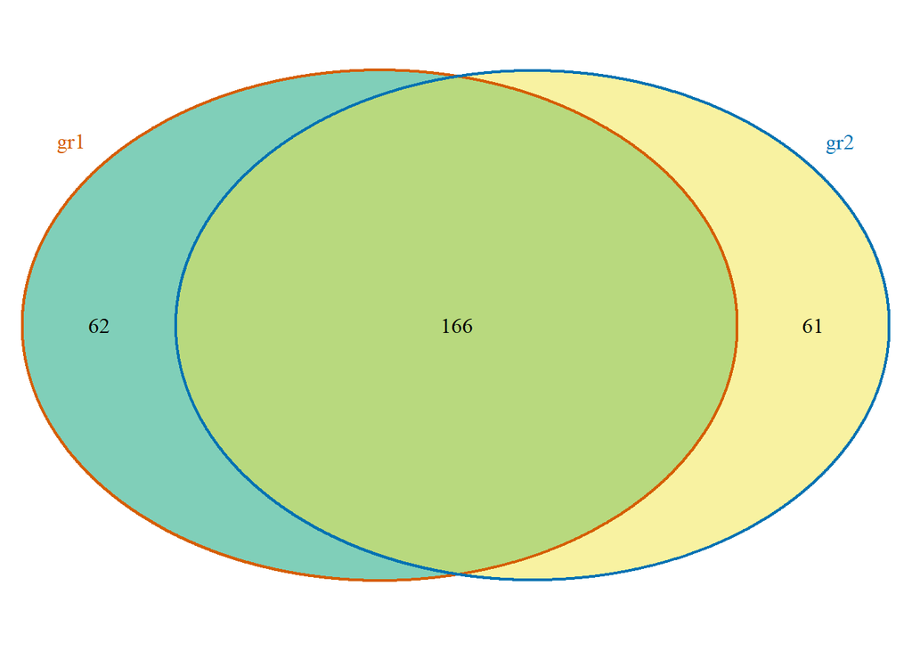

```
## $p.value
##      gr1 gr2 pval
## [1,]   1   1    0
##
## $vennCounts
##      gr1 gr2 Counts count.gr1 count.gr2
## [1,]   0   0      0         0         0
## [2,]   0   1     61         0        61
## [3,]   1   0     62        62         0
## [4,]   1   1    166       168       169
## attr(,"class")
## [1] "VennCounts"
```

```r
# Which type of object is "ol"?
# How many items does it have? List the items (hint: ol$)?

## create annotation file from EnsDb or TxDb
overlaps <- ol$peaklist[["gr1///gr2"]]

overlaps.anno <- annotatePeakInBatch(overlaps, AnnotationData=TSS.human.GRCh37,
                                    output="overlapping", maxgap=5000L)
overlaps.anno <- addGeneIDs(overlaps.anno, "org.Hs.eg.db", "symbol")
```

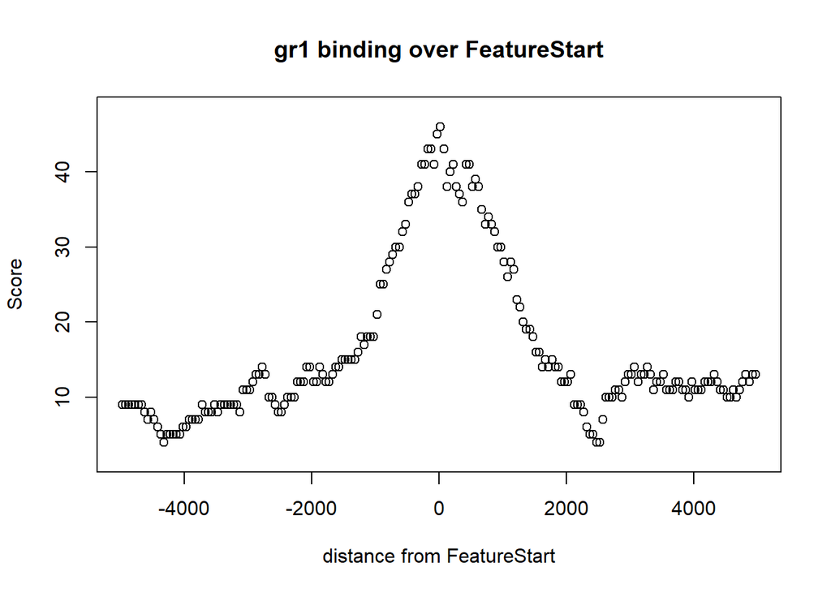

```r
# Is the gene SAMD11 present in overlaps.anno?
# HINT: Try the functions View() and as.data.frame() together

# Once the peaks are annotated, the distribution of the distance to the nearest
# feature such as the transcription start sites (TSS) can be plotted. The sample
# code here plots the distribution of the aggregated peak scores and the number
# of peaks around the TSS.
binOverFeature(gr1, annotationData=TSS.human.GRCh37,
               radius=5000, nbins=100, FUN=length, errFun = 0)
```

```r
# Where are the peaks centered around?

# The distribution of the peaks over exon, intron, enhancer, proximal promoter,
# 5’ UTR and 3’ UTR can be summarized in peak centric or nucleotide centric view
# using the function assignChromosomeRegion.
aCR<-assignChromosomeRegion(gr1, nucleotideLevel=FALSE,
                           precedence=c("Promoters", "immediateDownstream",
                                         "fiveUTRs", "threeUTRs",
                                         "Exons", "Introns"),
                           TxDb=TxDb.Hsapiens.UCSC.hg19.knownGene)
aCR$percentage
```

```
## subjectHits
##           Promoters immediateDownstream            fiveUTRs           threeUTRs
##           34.782609            3.913043            3.043478            3.043478
##               Exons             Introns   Intergenic.Region
##            4.782609           32.608696           17.826087
```

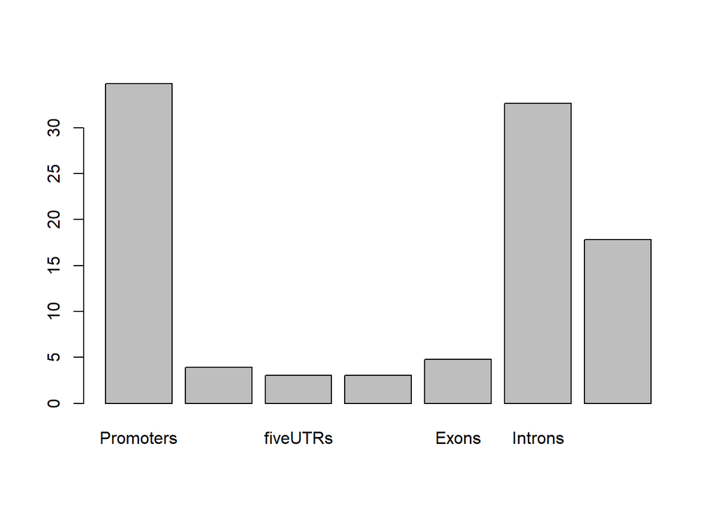

```r
barplot(aCR$percentage)
```

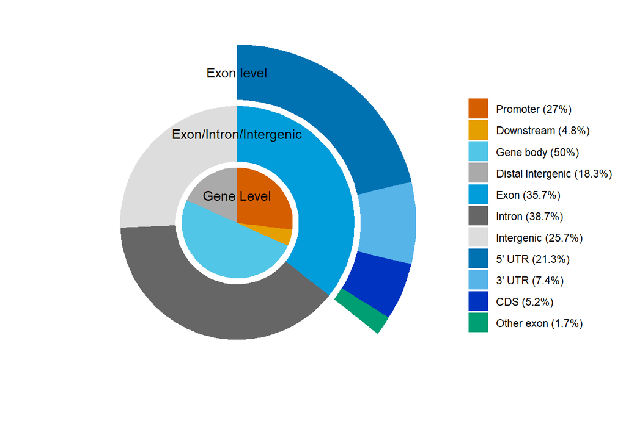

```r
# In which region most of the peaks are located?

# The percentages in the legend show the percentage of peaks in each category.
genomicElementDistribution(gr1,
                           TxDb = TxDb.Hsapiens.UCSC.hg19.knownGene,
                           promoterRegion=c(upstream=2000, downstream=500),
                           geneDownstream=c(upstream=0, downstream=2000))
```

```r
# Perform GO analysis
over <- getEnrichedGO(overlaps.anno, orgAnn="org.Hs.eg.db", condense=TRUE)
```

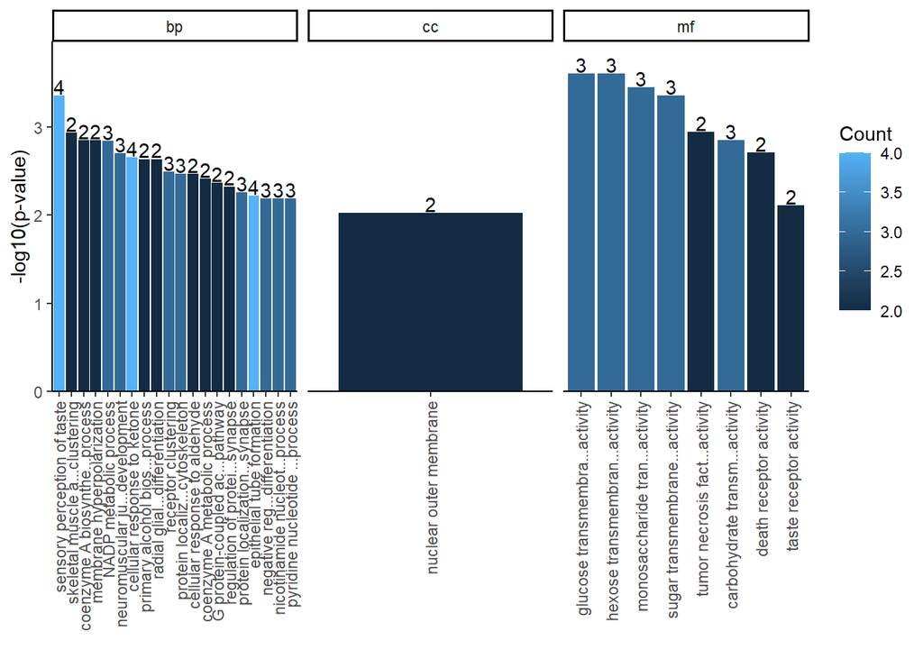

```r
enrichmentPlot(over)
```

```r
# Which is the most enriched biological process (bp)?
```

## DE pipeline

```r
# FOR HELP:
#  Press f1 on function name
#  ?function
#  Type on help tab

# 1. Load required libraries
library("DESeq2")
```

```r
library("pheatmap")
library("RColorBrewer")
library("ggplot2")

# 2. Get the working directory
getwd()
```

```
## [1] "C:/Users/rafae/OneDrive/Documentos/r_lesson"
```

```r
# 3. Get our files
download.file("https://raw.githubusercontent.com/rlbc/lesson/main/GSE60949_counts_1000.csv",
                      destfile = "GSE60949_counts_1000.csv")
download.file("https://raw.githubusercontent.com/rlbc/lesson/main/GSE60949-metadata.csv",
              destfile = "GSE60949-metadata.csv")

myCts <- "GSE60949_counts_1000.csv"
myMeta <- "GSE60949-metadata.csv"

# 4. Read the CSV file, taking the "row names" from "gene_symbol" column
# CSV = comma separated file
# We could read a tabular separated file (TSV) or other files with read.table()
cts <- read.csv(myCts, row.names = "gene_symbol")

# We can inspect the file
head(cts)
```

```
##              GSM1494412 GSM1494416 GSM1494413 GSM1494415
## EDRF1              1088        518        759        748
## CENPP               481        423        512        586
## RP11-278C7.2          0          0          6          0
## BST2                 24         92         29         70
## NPPC                  2         26          2         33
## NUDT19P5              0          0          5          0
```

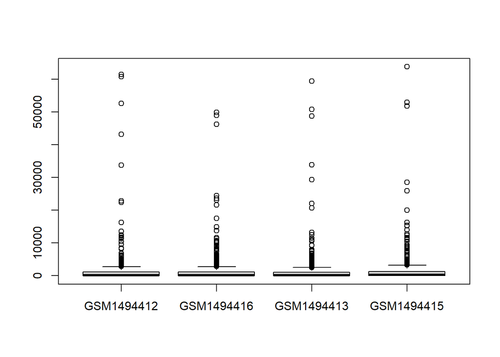

```r
# 5. Let's plot a simple boxplot to look at the data distribution
boxplot(cts)
```

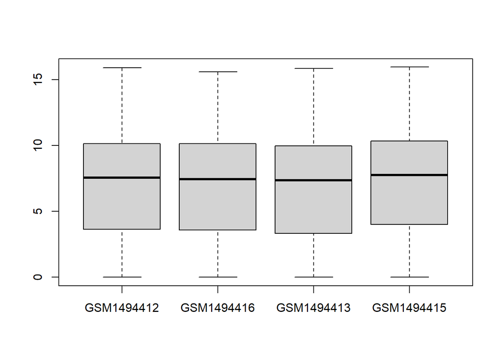

```r
# Can we see clearly the results?
# We can make it better by transforming the data with log2

boxplot(log2(cts + 1))
```

```r
# Why adding 1?
# Try without it (just log2(cts))

# 6. Read the metadata
coldata <- read.csv(myMeta, row.names=1)

# We can also inspect it
coldata
```

```
##                Sample cell_line treatment condition
## GSM1494412    shGFP-3      A673     shGFP     tumor
## GSM1494416 shEWS-FLI2      A673 shEWS-FLI    normal
## GSM1494413    shGFP-1      A673     shGFP     tumor
## GSM1494415 shEWS-FLI1      A673 shEWS-FLI    normal
```

```r
# 7. Generate a DESeqDataSet object
# A DESeqDataSet object must have an associated design formula. The design
# formula expresses the variables which will be used in modeling. The formula
# should be a tilde (~) followed by the variables with plus signs between them
# (it will be coerced into an formula if it is not already). The design can be
# changed later, however then all differential analysis steps should be
# repeated, as the design formula is used to estimate the dispersions and to
# estimate the log2 fold changes of the model.
dds <- DESeqDataSetFromMatrix(countData = cts,
                              colData = coldata,
                              design = ~ condition)

# Make sure we have normal - tumor
dds$condition <- relevel(dds$condition, ref = "normal")

# 8. Run DESeq
#  1. The estimation of size factors, controlling for differences in the counts
#  due varying sequencing depth of the samples.

#  2. The estimation of dispersion values. The dispersion parameter captures how
#  much the counts for the samples will vary around an expected value. Note that
#  the expected value takes into consideration the sequencing depth and
#  differences that can be attributed to variables in the design formula.

#  3. Fitting a final generalized linear model using the size factors and
#  dispersion values estimated above, which gives estimates of the log fold
#  changes.
dds <- DESeq(dds)
```

[figure not shown]

```r
# 9. Get normalized counts
# This function calculates a variance stabilizing transformation (VST) and then
# transforms the count data (normalized by division by the size factors or
# normalization factors). The transformation also normalizes with respect to
# library size. These transformations are useful when checking for outliers or
# as input for machine learning techniques such as clustering or linear
# discriminant analysis.
vsd <- varianceStabilizingTransformation(dds, blind = TRUE)

# We also can get the normalized counts, by library size
normalized_counts <- counts(dds, normalized = TRUE)

# Plot and compare the two values
boxplot(log2(normalized_counts + 1))
```

[figure not shown]

```r
boxplot(assay(vsd))
```

[figure not shown]

```r
# 10. Assess the dataset
# A useful first step in an RNA-seq analysis is often to assess overall
# similarity between samples: Which samples are similar to each other, which are
# different? Does this fit to the expectation from the experiment’s design? We
# use the R function dist to calculate the Euclidean distance between samples.
sampleDists <- dist(t(assay(vsd)))

sampleDistMatrix <- as.matrix(sampleDists)
rownames(sampleDistMatrix) <- paste(vsd$condition, vsd$Sample, sep="-")
colnames(sampleDistMatrix) <- NULL
colors <- colorRampPalette( rev(brewer.pal(9, "Blues")) )(255)
pheatmap(sampleDistMatrix,
         clustering_distance_rows=sampleDists,
         clustering_distance_cols=sampleDists,
         col=colors)
```

[figure not shown]

```r
# Another way to visualize sample-to-sample distances is a principal components
# analysis (PCA). In this ordination method, the data points (here, the samples)
# are projected onto the 2D plane such that they spread out in the two
# directions that capture the most of the variance across samples.
plotPCA(vsd, intgroup=c("condition", "Sample"))
```

[figure not shown]

```r
# A common method of visualizing gene expression data is to display it as a
# heatmap (Figure 12). The heatmap may also be combined with clustering methods
# which group genes and/or samples together based on the similarity of their
# gene expression pattern. This can be useful for identifying genes that are
# commonly regulated, or biological signatures associated with a particular
# condition
select <- order(rowVars(counts(dds,normalized=TRUE)),
                decreasing=TRUE)[1:20]
df <- as.data.frame(colData(dds)[,c("condition", "Sample")])

pheatmap(assay(vsd)[select,], cluster_rows=FALSE, show_rownames=FALSE,
         cluster_cols=TRUE, annotation_col=df)
```

```r
# 11. Get the differential expressed genes
# Calling results without any arguments will extract the estimated log2 fold
# changes and p values for the design formula.
res <- results(dds)

# Results columns
# The first column, baseMean, is a just the average of the normalized count
# values, dividing by size factors, taken over all samples in the DESeqDataSet.

# The column log2FoldChange is the effect size estimate. It tells us how much
# the gene’s expression seems to have changed due to treatment. This value is
# reported on a logarithmic scale to base 2: for example, a log2 fold change of
# 1.5 means that the gene’s expression is increased by a multiplicative factor
# of 21.5 ≈ 2.82.

# The column lfcSE estimate has an uncertainty associated with log2FoldChange,
# or the standard error estimate for the log2 fold change estimate.

# DESeq2 performs for each gene a hypothesis test to see whether evidence is
# sufficient to decide against the null hypothesis that there is zero effect of
# the treatment on the gene and that the observed difference between treatment
# and control was merely caused by experimental variability. As usual in
# statistics, the result of this test is reported as a p value, and it is found
# in the column pvalue. A p value indicates the probability that a fold change
# as strong as the observed one, or even stronger, would be seen under the
# situation described by the null hypothesis. The adjusted p values satisfy the
# property that thresholding at a specific value defines a set of tests (one for
# each gene) with a bounded false discovery rate (FDR), typically a useful
# metric for assessing which genes to target for further analysis.

# We can summarize the results of the differential expression
summary(res)
```

```
##
## out of 1000 with nonzero total read count
## adjusted p-value < 0.1
## LFC > 0 (up)       : 129, 13%
## LFC < 0 (down)     : 162, 16%
## outliers [1]       : 0, 0%
## low counts [2]     : 136, 14%
## (mean count < 5)
## [1] see 'cooksCutoff' argument of ?results
## [2] see 'independentFiltering' argument of ?results
```

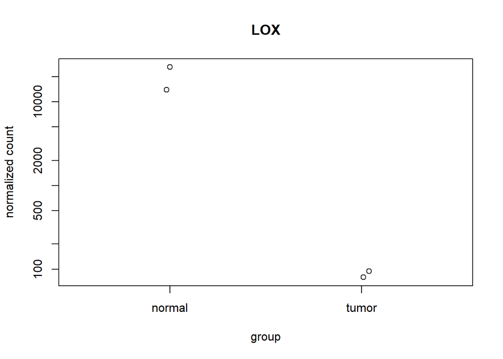

```r
# And order the results table by padj
resOrdered <- res[order(res$padj),]

# 12. Visualize and save the results
# Plotting counts for single genes
plotCounts(dds, gene="LOX", intgroup="condition")
```

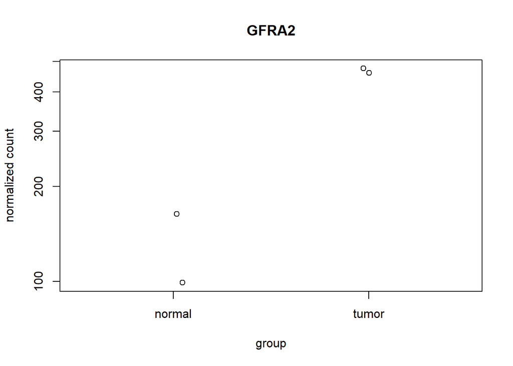

```r
plotCounts(dds, gene="GFRA2", intgroup="condition")
```

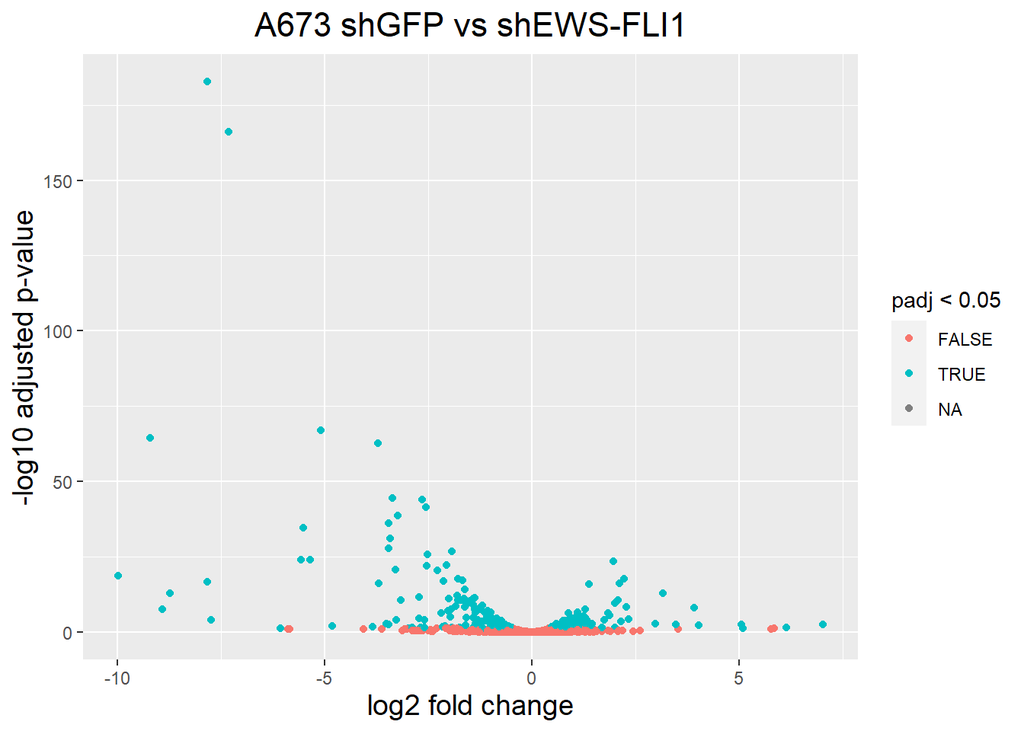

```r
# A volcano plot is a type of scatterplot that shows statistical significance (P
# value) versus magnitude of change (fold change). It enables quick visual
# identification of genes with large fold changes that are also statistically
# significant. These may be the most biologically significant genes.
ggplot(as.data.frame(res), aes(x = log2FoldChange, y = -log10(padj))) +
    geom_point(aes(colour = padj < 0.05)) +
    ggtitle("A673 shGFP vs shEWS-FLI1") +
    xlab("log2 fold change") +
    ylab("-log10 adjusted p-value") +
    theme(plot.title = element_text(size = rel(1.5), hjust = 0.5),
          axis.title = element_text(size = rel(1.25)))
```

```r
# Write data to file
write.csv(as.data.frame(resOrdered),
          file="condition_treated_results.csv")
```